# Practical Machine Learning Project

Jeff Jetton

## Summary

In an attempt to predict the class of exercise movement based on sensor data input, the training set of sensor data was (after some cleaning) split into a training set and an additional cross-validation “hold out” set. Models were developed and tested primarily using the training set, with a final accuracy estimate confirmed with the hold-out set.

A random forest model was found to yield the highest estimated accuracy, and it was this model that was applied to the final test set.

## Data Processing

### Loading the Data

The provided training and test data were loaded into R and confirmed to be of the appropriate size.

```r
traindata <- read.csv("pml-training.csv")
testdata <- read.csv("pml-testing.csv")
dim(traindata); dim(testdata)
```

```
## [1] 19622   160
```

```
## [1]  20 160
```

### Data Cleaning and Processing

A cursory examination of the data showed some columns that were obviously identifying metadata, as well as many columns that consisted almost entirely of missing data (NAs). These columns were removed from both the training and test sets.

```r
keepcols <- c(8:11, 37:49, 60:68, 84:86, 102, 113:124, 151:160)
traindata <- traindata[ , keepcols]
testdata <- testdata[  , keepcols]
dim(traindata); dim(testdata)
```

```
## [1] 19622    52
```

```
## [1] 20 52
```

The training data was then randomly split into a primary training set (70%) and a separate hold-out set (30%) for further cross-validation.

```r
require(caret)
set.seed(24601)
inTrain <- createDataPartition(y=traindata$classe, p=0.70, list=FALSE)
trainset <- traindata[ inTrain, ]
holdoutset  <- traindata[ -inTrain, ]
dim(trainset); dim(holdoutset)
```

```
## [1] 13737    52
```

```
## [1] 5885   52
```

### Determining Principal Components

```r
# The 52nd column is our outcome variable. We do not include it in the PCA preprocessing.
pca.preprocessor <- preProcess(trainset[ , -52], method="pca")
trainset.pca <- predict(pca.preprocessor, newdata=trainset[ , -52])
holdoutset.pca <- predict(pca.preprocessor, newdata=holdoutset[ , -52])
dim(trainset.pca); dim(holdoutset.pca)
```

```
## [1] 13737    24
```

```
## [1] 5885   24
```

We can see that the first 24 principal components are indeed responsible for 95% of the variance:

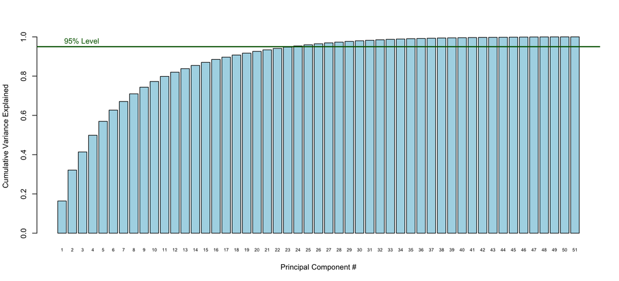

## Model Building and Comparison

Several models were tried, both with and without PCA. The `train()` function from the **caret** package was used, which automatically cycles through an appropriate set of tuning parameters and estimates out-of-sample accuracy for each configuration using multiple copies of a bootstrapped data set.

The best accuracy levels for each model type were as follows:

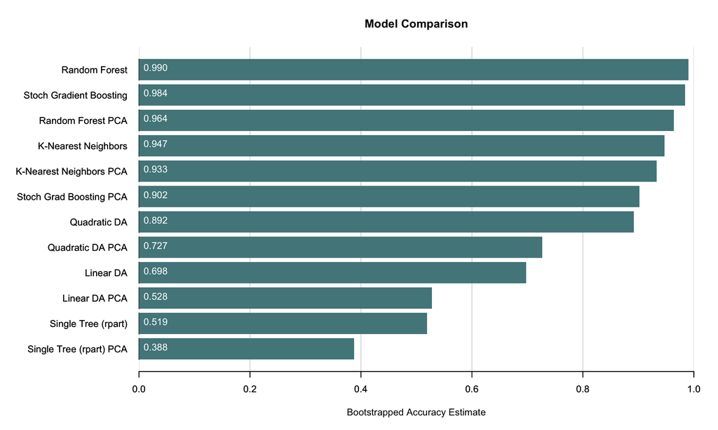

## Evaluating the Winning Model

The highest bootstrapped accuracy (0.99) was obtained with the **Random Forest** algorithm applied to the raw (non-PCA) data.

By default, caret’s train function will cycle through several different values of the `mtry` parameter (indicating the number of features to randomly select for each tree in the forest). In practice, there was found to be little difference in estimated accuracy among the various values. For speed, we fixed the `mtry` parameter to approximately the square root of the number of features, which is the default behavior for the `randomForest()` function.

The estimated accuracy was determined by applying the model to five bootstrapped sample sets.

```r
customGrid <- data.frame(mtry=floor(sqrt(ncol(trainset[ ,-52]))))
tcon <- trainControl(number=5)
set.seed(8675309)
fit <- train(classe ~ ., data=trainset, method="rf",
             tuneGrid=customGrid, trControl=tcon)
```

```r
fit
```

```
## Random Forest
##
## 13737 samples
##    51 predictor
##     5 classes: 'A', 'B', 'C', 'D', 'E'
##
## No pre-processing
## Resampling: Bootstrapped (5 reps)
## Summary of sample sizes: 13737, 13737, 13737, 13737, 13737
## Resampling results
##
##   Accuracy   Kappa      Accuracy SD  Kappa SD
##   0.9900869  0.9874613  0.001559403  0.001970364
##
## Tuning parameter 'mtry' was held constant at a value of 7
##
```

Our final estimate of expected out-of-sample accuracy is determine by applying our model to the held-out cross-validation set. We then compare the predicted outcomes to the actual outcomes.

```r
holdoutpred <- predict(fit, holdoutset)
cm <- confusionMatrix(holdoutpred, holdoutset$classe)
cm$table
```

```
##           Reference
## Prediction    A    B    C    D    E
##          A 1673    4    0    0    0
##          B    1 1135    4    0    0
##          C    0    0 1021    8    0
##          D    0    0    1  956    7
##          E    0    0    0    0 1075
```

```r
data.frame(value=round(cm$overall, 3))
```

```
##                value
## Accuracy       0.996
## Kappa          0.995
## AccuracyLower  0.994
## AccuracyUpper  0.997
## AccuracyNull   0.284
## AccuracyPValue 0.000
## McnemarPValue    NaN
```

The expected out-of-sample accuracy found with the hold-out set is 0.996, even slightly better than the previous estimate of 0.99 found via bootstrapping.

## Prediction

The random forest model was finally applied to the provided test data and a vector of predicted `classe` values was obtained.

```r
answers <- as.character(predict(fit, testdata))
answers
```

```
##  [1] "B" "A" "B" "A" "A" "E" "D" "B" "A" "A" "B" "C" "B" "A" "E" "E" "A"
## [18] "B" "B" "B"
```